**Title: “Fundamental machine learning assignment-1”**

**Author: “Venkata Sai Reddy”**

**Date: “31-01-2025”**

##Question - 1

#Introduction: In this Rmarkdown document provides you the usage of basic descriptive statistics like head,tail,dimensions, summary, structure, mean, mode, median, is.na done using the Churn.csv data file.

```r
# Load required  libraries
library(dplyr)
library(readr)
```

```r
# Read the dataset and assign it to Churn variable

Churn <- read_csv("C:/FML_R/Churn.csv")
# Display first few rows

##Default value is 6 rows

head(Churn)
```

```
## # A tibble: 6 × 9
##   CallFailures SubscriptionLength DataUsage VoiceMinutes CustomerSupportCalls
##          <dbl>              <dbl>     <dbl>        <dbl>                <dbl>
## 1           16                 11     4.19         4836.                    2
## 2            4                  9     8.41         1695.                    5
## 3            0                  8     0.654        4384.                    3
## 4            9                  9     8.83         2610.                    0
## 5            3                  8     7.25         2890.                    3
## 6           17                  3     0.808        1207.                    1
## # ℹ 4 more variables: ContractType <chr>, MonthlyCharges <dbl>,
## #   RoamingUsage <dbl>, Churn <dbl>
```

```r
##for specific number of rows

head(Churn , 10)
```

```
## # A tibble: 10 × 9
##    CallFailures SubscriptionLength DataUsage VoiceMinutes CustomerSupportCalls
##           <dbl>              <dbl>     <dbl>        <dbl>                <dbl>
##  1           16                 11     4.19         4836.                    2
##  2            4                  9     8.41         1695.                    5
##  3            0                  8     0.654        4384.                    3
##  4            9                  9     8.83         2610.                    0
##  5            3                  8     7.25         2890.                    3
##  6           17                  3     0.808        1207.                    1
##  7           16                  8     1.00          460.                    1
##  8           14                 10     8.14          401.                    4
##  9            6                 10     1.22         4800.                    3
## 10            3                  2     7.82         1725.                    1
## # ℹ 4 more variables: ContractType <chr>, MonthlyCharges <dbl>,
## #   RoamingUsage <dbl>, Churn <dbl>
```

```r
#Display last few rows

## Default value is 6 rows

tail(Churn)
```

```
## # A tibble: 6 × 9
##   CallFailures SubscriptionLength DataUsage VoiceMinutes CustomerSupportCalls
##          <dbl>              <dbl>     <dbl>        <dbl>                <dbl>
## 1            9                 18     6.69         3231.                    4
## 2           14                 13     0.368         221.                    4
## 3           18                 18     3.34         1332.                    4
## 4           11                  5     7.04         4889.                    4
## 5           17                 14     3.95         2522.                    5
## 6           17                 10     0.256        2508.                    4
## # ℹ 4 more variables: ContractType <chr>, MonthlyCharges <dbl>,
## #   RoamingUsage <dbl>, Churn <dbl>
```

```r
## for specific number of rows

tail(Churn , 10)
```

```
## # A tibble: 10 × 9
##    CallFailures SubscriptionLength DataUsage VoiceMinutes CustomerSupportCalls
##           <dbl>              <dbl>     <dbl>        <dbl>                <dbl>
##  1           20                  5     6.29         1990.                    5
##  2            9                 15     4.59         1932.                    3
##  3            2                 19     3.31         4423.                    2
##  4            1                 14     4.17          363.                    0
##  5            9                 18     6.69         3231.                    4
##  6           14                 13     0.368         221.                    4
##  7           18                 18     3.34         1332.                    4
##  8           11                  5     7.04         4889.                    4
##  9           17                 14     3.95         2522.                    5
## 10           17                 10     0.256        2508.                    4
## # ℹ 4 more variables: ContractType <chr>, MonthlyCharges <dbl>,
## #   RoamingUsage <dbl>, Churn <dbl>
```

```r
# Get dataset dimensions

## for number of rows

nrow(Churn)
```

```
## [1] 1000
```

```r
## for number of columns

ncol(Churn)
```

```
## [1] 9
```

```r
## for both Number of rows & columns

dim(Churn)
```

```
## [1] 1000    9
```

```r
# Get summary statistics
summary(Churn)
```

```
##   CallFailures    SubscriptionLength   DataUsage        VoiceMinutes
##  Min.   : 0.000   Min.   : 1.00      Min.   :0.04479   Min.   :   1.913
##  1st Qu.: 5.000   1st Qu.: 6.00      1st Qu.:2.45883   1st Qu.:1392.148
##  Median :10.000   Median :12.00      Median :5.07325   Median :2626.685
##  Mean   : 9.985   Mean   :12.09      Mean   :5.09635   Mean   :2564.964
##  3rd Qu.:16.000   3rd Qu.:18.00      3rd Qu.:7.82260   3rd Qu.:3712.721
##  Max.   :20.000   Max.   :24.00      Max.   :9.99831   Max.   :4998.703
##  CustomerSupportCalls ContractType       MonthlyCharges   RoamingUsage
##  Min.   :0.000        Length:1000        Min.   :20.07   Min.   :0.01345
##  1st Qu.:1.000        Class :character   1st Qu.:37.57   1st Qu.:2.32212
##  Median :2.000        Mode  :character   Median :56.91   Median :4.94221
##  Mean   :2.394                           Mean   :58.42   Mean   :4.95070
##  3rd Qu.:4.000                           3rd Qu.:77.45   3rd Qu.:7.44860
##  Max.   :5.000                           Max.   :99.96   Max.   :9.99680
##      Churn
##  Min.   :0.000
##  1st Qu.:0.000
##  Median :1.000
##  Mean   :0.504
##  3rd Qu.:1.000
##  Max.   :1.000
```

```r
## for any perticular column summary statistics

summary(Churn$ VoiceMinutes)
```

```
##     Min.  1st Qu.   Median     Mean  3rd Qu.     Max.
##    1.913 1392.148 2626.685 2564.964 3712.721 4998.703
```

```r
summary(Churn$ CallFailures)
```

```
##    Min. 1st Qu.  Median    Mean 3rd Qu.    Max.
##   0.000   5.000  10.000   9.985  16.000  20.000
```

```r
summary(Churn$ Churn)
```

```
##    Min. 1st Qu.  Median    Mean 3rd Qu.    Max.
##   0.000   0.000   1.000   0.504   1.000   1.000
```

```r
table (Churn$Churn)
```

```
##
##   0   1
## 496 504
```

```r
# Structure of dataset

str(Churn)
```

```
## spc_tbl_ [1,000 × 9] (S3: spec_tbl_df/tbl_df/tbl/data.frame)
##  $ CallFailures        : num [1:1000] 16 4 0 9 3 17 16 14 6 3 ...
##  $ SubscriptionLength  : num [1:1000] 11 9 8 9 8 3 8 10 10 2 ...
##  $ DataUsage           : num [1:1000] 4.194 8.409 0.654 8.833 7.246 ...
##  $ VoiceMinutes        : num [1:1000] 4836 1695 4384 2610 2890 ...
##  $ CustomerSupportCalls: num [1:1000] 2 5 3 0 3 1 1 4 3 1 ...
##  $ ContractType        : chr [1:1000] "Monthly" "Monthly" "Monthly" "Monthly" ...
##  $ MonthlyCharges      : num [1:1000] 24.3 82.5 52.9 32.3 58.2 ...
##  $ RoamingUsage        : num [1:1000] 2.6 5.28 3.17 3.03 8.91 ...
##  $ Churn               : num [1:1000] 0 1 0 0 0 1 1 1 0 0 ...
##  - attr(*, "spec")=
##   .. cols(
##   ..   CallFailures = col_double(),
##   ..   SubscriptionLength = col_double(),
##   ..   DataUsage = col_double(),
##   ..   VoiceMinutes = col_double(),
##   ..   CustomerSupportCalls = col_double(),
##   ..   ContractType = col_character(),
##   ..   MonthlyCharges = col_double(),
##   ..   RoamingUsage = col_double(),
##   ..   Churn = col_double()
##   .. )
##  - attr(*, "problems")=<externalptr>
```

```r
## To check data type for specific column

class(Churn$ MonthlyCharges)
```

```
## [1] "numeric"
```

```r
# To Get mean for Respective columns
mean(Churn$CallFailures)
```

```
## [1] 9.985
```

```r
mean(Churn$SubscriptionLength)
```

```
## [1] 12.093
```

```r
mean(Churn$DataUsage)
```

```
## [1] 5.096345
```

```r
mean(Churn$VoiceMinutes)
```

```
## [1] 2564.964
```

```r
mean(Churn$CustomerSupportCalls)
```

```
## [1] 2.394
```

```r
mean(Churn$MonthlyCharges)
```

```
## [1] 58.41586
```

```r
mean(Churn$RoamingUsage)
```

```
## [1] 4.950701
```

```r
mean(Churn$Churn)
```

```
## [1] 0.504
```

```r
# To Get median for Respective columns
median(Churn$CallFailures)
```

```
## [1] 10
```

```r
median(Churn$SubscriptionLength)
```

```
## [1] 12
```

```r
median(Churn$DataUsage)
```

```
## [1] 5.073246
```

```r
median(Churn$VoiceMinutes)
```

```
## [1] 2626.685
```

```r
median(Churn$CustomerSupportCalls)
```

```
## [1] 2
```

```r
median(Churn$MonthlyCharges)
```

```
## [1] 56.91449
```

```r
median(Churn$RoamingUsage)
```

```
## [1] 4.942205
```

```r
median(Churn$Churn)
```

```
## [1] 1
```

```r
# Function to calculate mode
mode_function <- function(v) {
  unique_values <- unique(v)
  unique_values[which.max(tabulate(match(v, unique_values)))]
}

# Compute mode for each column
sapply(Churn, mode_function)
```

```
##         CallFailures   SubscriptionLength            DataUsage
##                  "9"                 "12"   "4.19360703555867"
##         VoiceMinutes CustomerSupportCalls         ContractType
##   "4836.25042135827"                  "0"            "Monthly"
##       MonthlyCharges         RoamingUsage                Churn
##   "24.2686576396227"   "2.60071393335238"                  "1"
```

```r
# Check for missing values
any(is.na(Churn)) # Return "True" if there are any missing values
```

```
## [1] FALSE
```

```r
sum(is.na(Churn)) #Return "0" if there are any missing value
```

```
## [1] 0
```

## Question - 2

# **Interpretation for Basic Descriptive Statistics**

#Introduction: In this Rmarkdown document provides you the interpretation of the Basic Descriptive statistics for the summary, missing value check ,Key takeaways form that and conclusion.

# Understanding the Dataset and Key Insights

## 1. Overview of the Dataset

The dataset contains customer information related to telecom service usage. The primary goal is to analyze factors that influence customer churn (i.e., whether a customer continues using the service or leaves). Key variables include **Call Failures, Subscription Length, Data Usage, Voice Minutes, Customer Support Calls, Monthly Charges, and Roaming Usage**.

## 2. Summary of Key Findings

We analyzed the dataset using various statistical measures like mean, median, mode, and missing value checks. Below are the key observations:

### Call Failures

- The average number of failed call attempts is **9.99**, and the median is **10**.
- This means that, on average, customers experience around 10 failed calls. A high number of call failures may lead to frustration, increasing churn risk.

### Data Usage

- The average data usage is **5.09 GB**, with a median of **5.07 GB**.
- Higher data usage may indicate engaged customers, but those who use excessive data could also be at risk of churn if they feel their data plans are expensive.

### Voice Minutes

- Customers make an average of **2564.96 minutes** of voice calls.
- A drop in voice usage might indicate dissatisfaction with call quality or a shift to internet-based calling services.

### Customer Support Calls

- Customers contact customer support **2.39 times on average**.
- Frequent support calls might suggest service issues, which could lead to churn if problems remain unresolved.

### Monthly Charges

- The average monthly bill is **₹58.41**.
- If customers feel they are being overcharged without receiving adequate value, they might switch to competitors with better pricing.

### Roaming Usage

- Customers use around **4.95 units** of roaming services on average.
- Higher roaming usage might lead to dissatisfaction if roaming charges are too high.

### Churn Rate

- The churn rate is **50.4%**, meaning about half of the customers have left the service.
- This suggests that customer retention is a significant challenge for the telecom company.

## 3. Missing Value Check

- There are **no missing values** in the dataset, ensuring that all data points are complete and ready for analysis.

## 4. Key Takeaways

- **High call failures and frequent customer support calls** are warning signs of customer dissatisfaction.
- **Customers with high monthly charges** might leave due to cost concerns.
- **Churn rate is balanced (around 50%)**, indicating an opportunity to improve retention strategies.
- **No missing values** mean the dataset is reliable for further analysis.

### Conclusion

By analyzing these factors, telecom companies can identify patterns and take proactive steps to improve customer satisfaction. For example, they can enhance network quality, offer better pricing plans, and provide efficient customer service to reduce churn rates.

## Question - 3

# ** comparison between two columns of Churn through visualization**

#introduction: In this R markdown provide with the comparison of the RoamingUsage column and Churn column. The comparison is visualized in the Box plot manner.

[figure not shown]

```r
# Load requried library
library(readr)
library(ggplot2)

# Read the dataset and assign it to Churn variable
Churn <- read_csv("C:/FML_R/Churn.csv")
# Convert Churn to a factor for better visualization
Factor_Churn <- as.factor(Churn$Churn)

#RoamingUsage is assigned to Roam with out skewness
Roam <- c(Churn$RoamingUsage)

# Scatter plot with trend line for Data Usage vs. Churn
ggplot(Churn, aes(y = Roam, x = Factor_Churn, fill = Factor_Churn)) +
  geom_boxplot() +  # Box plot Representation
  labs(
    title = "Box plot of Square root transformed MonthlyCharges and Churn",
    y = "Roaming usage ",
    x = "Churn Status"
  ) +
  theme_minimal() +
  scale_fill_manual(values =  c("lightgreen","orange"))
```

## Question-4

#Introduction: In this R Markdown document provided with detailed breakdown of R Code to transform VoiceMinutes variable into log() and create a histogram plot using ggplot2 package for log transformed voice minute variable.

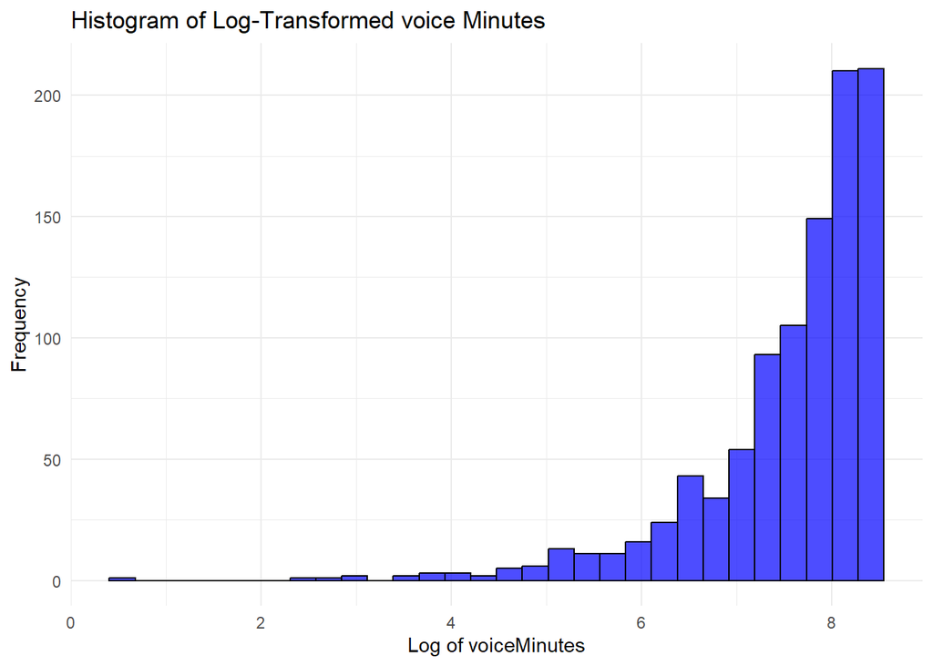

```r
knitr::opts_chunk$set(echo = TRUE)
 #Load required library
library(ggplot2)  # For visualization

# Read the dataset
Churn <- read.csv("C:/FML_R/Churn.csv")

# Apply log transformation to Voice Minutes (avoiding zero values)
log_VM <- log(Churn$VoiceMinutes)  # Adding 1 to prevent log(0) error
# Create a plot for the log-transformed MonthlyCharges variable

ggplot(Churn, aes(x = log_VM)) +
  geom_histogram(bin = 30, fill = 'blue', color = 'black', alpha = 0.7) +
  labs(
    title = "Histogram of Log-Transformed voice Minutes",
    x = "Log of voiceMinutes",
    y = "Frequency"
  ) +
  theme_minimal() # To have a faded background in histogram
```

#Interpretation:

1. Most of the customers have a voice minutes between 6 and 8.
2. Very few customers have a voice minutes between 2 and 4.
3. There are no customers who does not use voice.